# Discovering batokines from BAT RNA-seq

Nagendra Palani / nagendra.palani@sund.ku.dk

updated: 03-Nov-2020

### Preprocessing

In vitro cultures of brown adipocytes treated with +/- norepinephrine were subject to RNA-seq. Fastq files were aligned with STAR to human ref. genome and then counts collated using featureCounts (ensembl 101). See GEO accession GSE150119 - supraclavicular adipose tissue samples GSM4523813 - GSM452382 for sequencing data.

NOTE: log2FC is calculated for NE/control here.

#### Dependencies

```r
library(tidyverse)
library(DESeq2)
library(DEGreport)
library(patchwork)
library(readr)
library(RColorBrewer)
library(biomaRt)
library(pheatmap)
library(ggthemes)
library(EnhancedVolcano)
```

#### Samples from subject 2 were excluded as the samples had an outsized influence from the subject and not the treatment.

```r
# setwd to ~/Documents/sus_invivocool/bat_NE_vs_control_final

 cts <- read_delim("featcount_batcontrolvsne.txt", "\t", escape_double = FALSE, col_types = cols(Chr = col_skip(), Start = col_skip(), End = col_skip(), Strand = col_skip(), Length = col_skip(),`3_sample` = col_skip(),`4_sample`=col_skip()), trim_ws = TRUE)

coldata <- read_csv("bat_controlne_cleaned_coldata.csv", col_types = cols(condition = col_factor(levels = c("control", "treated")), subject = col_factor(levels = c("1", "3", "4","5"))))
```

#### Check if count samples names and coldata sample names match

```r
cts <- data.frame(cts, row.names = 1)
coldata <- data.frame(coldata, row.names = 1)

# rearrange columns of cts based on coldata order.
cts <- cts[,rownames(coldata)]
all(rownames(coldata) == colnames(cts))
```

```
[1] TRUE
```

#### Assemble DESeq object

```r
dds <- DESeqDataSetFromMatrix(countData = cts,
                              colData = coldata,
                              design = ~ subject + condition)
dds$tissue <- relevel(dds$condition, ref = "control")

dds
```

```
class: DESeqDataSet
dim: 60671 8
metadata(1): version
assays(1): counts
rownames(60671): ENSG00000223972 ENSG00000227232 ... ENSG00000277475 ENSG00000268674
rowData names(0):
colnames(8): X1_sample X2_sample ... X9_sample X10_sample
colData names(3): condition subject tissue
```

#### Run DESeq

```r
dds <- DESeq(dds)
res <- results(dds)
res
```

```
log2 fold change (MLE): condition treated vs control
Wald test p-value: condition treated vs control
DataFrame with 60671 rows and 6 columns
                  baseMean log2FoldChange     lfcSE      stat    pvalue      padj
                 <numeric>      <numeric> <numeric> <numeric> <numeric> <numeric>
ENSG00000223972    1.44691      -1.812788  1.984654 -0.913403  0.361031        NA
ENSG00000227232  126.65417      -0.260841  0.222655 -1.171503  0.241397  0.441693
ENSG00000278267   31.29393       0.350853  0.413608  0.848275  0.396285  0.606468
ENSG00000243485    2.11964       0.309064  1.819778  0.169836  0.865139        NA
ENSG00000284332    0.00000             NA        NA        NA        NA        NA
...                    ...            ...       ...       ...       ...       ...
ENSG00000271254 833.598230      -0.193211 0.0957432 -2.018010 0.0435902  0.124358
ENSG00000275405   1.160691      -0.445326 2.2619905 -0.196873 0.8439266        NA
ENSG00000275987   0.806184       1.151295 3.4690424  0.331877 0.7399821        NA
ENSG00000277475   0.000000             NA        NA        NA        NA        NA
ENSG00000268674   0.000000             NA        NA        NA        NA        NA
```

#### Plot dispersion estimate

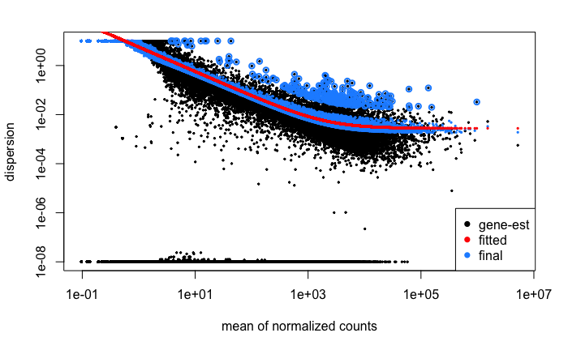

```r
plotDispEsts(dds)
```

#### Calculate rlog of counts for sample distance plots etc.

```r
rld <- rlog(dds, blind=TRUE)
rld_mat <- assay(rld)
```

#### Sample Distance plot

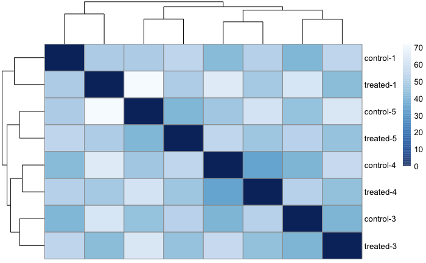

```r
sampleDists <- dist(t(assay(rld)))

sampleDistMatrix <- as.matrix(sampleDists)
rownames(sampleDistMatrix) <- paste(rld$condition, rld$subject, sep="-")
colnames(sampleDistMatrix) <- NULL
colors <- colorRampPalette( rev(brewer.pal(9, "Blues")) )(255)
pheatmap(sampleDistMatrix,
         clustering_distance_rows=sampleDists,
         clustering_distance_cols=sampleDists,
         col=colors)
```

#### PCA plot to see separation of samples.

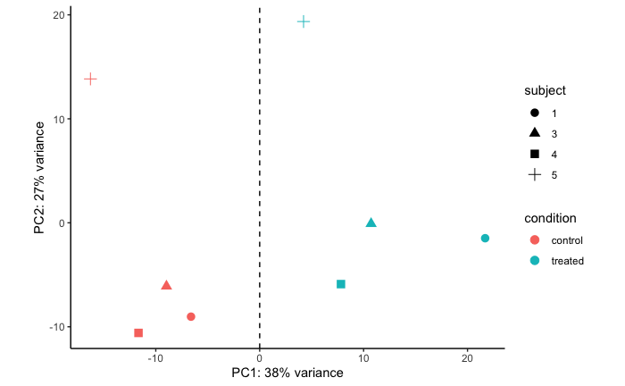

```r
pcaData <- plotPCA(rld, intgroup=c("condition","subject"), returnData=TRUE)
percentVar <- round(100 * attr(pcaData, "percentVar"))
pca_allgenes <- ggplot(pcaData, aes(PC1, PC2, color=condition, shape=subject)) +
  geom_jitter(size=3,width=1.5) + geom_vline(xintercept = 0,linetype = 2,colour="black") +
  xlab(paste0("PC1: ",percentVar[1],"% variance")) +
  ylab(paste0("PC2: ",percentVar[2],"% variance")) +
  coord_fixed() + theme_classic()

pca_allgenes
```

#### Summary of DE result

```r
resOrdered <- res[order(res$pvalue),]
resSig <- subset(resOrdered, padj < 0.05)
siggenes <- as.data.frame(resSig)



res05 <- results(dds, alpha=0.05)
summary(res05)
```

```
out of 39578 with nonzero total read count
adjusted p-value < 0.05
LFC > 0 (up)       : 3456, 8.7%
LFC < 0 (down)     : 2692, 6.8%
outliers [1]       : 0, 0%
low counts [2]     : 18645, 47%
(mean count < 9)
[1] see 'cooksCutoff' argument of ?results
[2] see 'independentFiltering' argument of ?results
```

```r
# Normalized counts
normalized_counts <- counts(dds, normalized=T)
```

#### Annotate DE genes using BiomaRt

```r
siggenedf <- data.frame(ensemblid = row.names(siggenes), siggenes,stringsAsFactors=FALSE)
rownames(siggenedf) <- NULL

mart <- useDataset("hsapiens_gene_ensembl", useMart("ensembl"))

G_list <- getBM(filters= "ensembl_gene_id", attributes= c("ensembl_gene_id","hgnc_symbol","gene_biotype","description"),values=siggenedf$ensemblid,mart= mart)
de_list_all <- merge(siggenedf,G_list,by.x="ensemblid",by.y="ensembl_gene_id")

# Uncomment line below to get csv file of DE genes.
#write.csv(de_list_all, "bat_NE_vs_control_sub2excluded.csv")
```

#### Import list of secreted genes from Uhlen et al 2019 Science Signaling paper.

#### Subset the DE genes to contain only the secreted genes. Set lfcSE to =< 0.5

```r
secprot <- read_delim("secreted_proteins_list.txt", "\t", escape_double = FALSE, trim_ws = TRUE)
secprot$annotcategory <- as.factor(secprot$annotcategory)

sigsecgenes <- inner_join(de_list_all,secprot,by="ensemblid")

sigsecgenes <- filter(sigsecgenes,lfcSE <= 0.5)
```

#### Data for Table 1 : BAT secretome summary by secretion location.

```r
#
totsecprot <- table(secprot$annotcategory) %>% as.data.frame()
batnesecprot <- table(sigsecgenes$annotcategory)%>% as.data.frame()


batup_seclist <- sigsecgenes %>% filter(log2FoldChange > 0)
batup_sec <- table(batup_seclist$annotcategory)%>% as.data.frame()

batdown_seclist <- sigsecgenes %>% filter(log2FoldChange < 0)
batdown_sec <- table(batdown_seclist$annotcategory)%>% as.data.frame()

ff <- secprot$ensemblid %in% rownames(normalized_counts)
secgenes_normcount <- normalized_counts[secprot$ensemblid[ff],]

# number of secreted genes that have a cumulative read count of > 10 across samples.
summary(rowSums(secgenes_normcount) >= 10)
```

```
   Mode   FALSE    TRUE
logical     642    1997
```

#### Heatmap of secreted genes n = 550

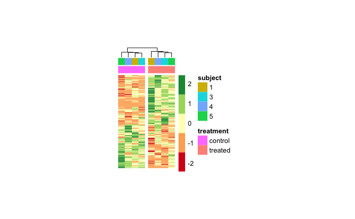

```r
#

### Extract normalized expression for significant genes


sigsecgenes <- arrange(sigsecgenes,annotcategory)
normcount_sig <- normalized_counts[sigsecgenes$ensemblid,]

my_sample_col <- data.frame(treatment = coldata$condition, subject=coldata$subject )
row.names(my_sample_col) <- colnames(normcount_sig)

heat.colors <- brewer.pal(5, "RdYlGn")

pheatmap(normcount_sig, color = heat.colors, cluster_rows = T,  show_rownames=F, cluster_cols = T, border_color=NA, fontsize = 10, scale="row",fontsize_row = 1, annotation_col = my_sample_col,cutree_cols = 2,treeheight_row = 0,treeheight_col=10,show_colnames = F, cellheight=0.25, cellwidth=10,annotation_names_col=F,width=5, height=5)
```

```r
# to save heatmap as pdf, add the following argument to the pheatmap command.
#filename="transbato_heatmap_pdf.pdf"
```

#### GO analysis

```r
#retrieve GO terms for genes from biomart
go_list <- getBM(filters= "ensembl_gene_id", attributes= c("ensembl_gene_id","hgnc_symbol","go_id","name_1006","definition_1006","namespace_1003"),values=sigsecgenes$ensemblid,mart= mart)
```

After retrieving the GO terms for all the secreted genes, the list was opened in an text editor and the genes which had the GO categories

Cell differentiation (GO:0030154) Hormone activity (GO:0005179) Growth factor activity (GO:0008083)

were extracted. Next, from these lists, only those genes that had a log2FC > 1 were retained. The gene INHBA was common to all three categories, so that was dropped for visualization. Each GO gene list was then assigned a unique color for labeling on the Volcano plot.

The lists were imported into R.

```r
# Get upregulated genes for each GO category
genes_celldiff <- read_csv("genes_celldiff.txt", col_names = FALSE)
genes_hormoneactivity <- read_csv("genes_hormoneactivity.txt", col_names = FALSE)
genes_growthfactor <- read_csv("genes_growthactivity.txt", col_names = FALSE)

celldiff_de <- sigsecgenes %>% inner_join(genes_celldiff,by=c("ensemblid"="X1"))
celldiff_de_pos <- celldiff_de %>% filter(log2FoldChange >=1 ) %>% .[,8]

hormact_de <- sigsecgenes %>% inner_join(genes_hormoneactivity,by=c("ensemblid"="X1"))
hormact_de_pos <- hormact_de %>% filter(log2FoldChange >=1 ) %>% .[,8]

growthfac_de <- sigsecgenes %>% inner_join(genes_growthfactor,by=c("ensemblid"="X1"))
growthfac_de_pos <- growthfac_de  %>% filter(log2FoldChange >=1 ) %>% .[,8]

#get upregulated genes from all DE secreted genes
topreggenes <- sigsecgenes %>% filter(abs(log2FoldChange) >=1.5 ) %>% .[,8]

#remove INHBA
celldiff_de_pos <- celldiff_de_pos[!celldiff_de_pos %in% "INHBA"]
hormact_de_pos <- hormact_de_pos[!hormact_de_pos %in% "INHBA"]
growthfac_de_pos <- growthfac_de_pos[!growthfac_de_pos %in% "INHBA"]


#make non-redundant list of genes for labeling

topdiffs <- Reduce(setdiff, list(A = topreggenes,
                              B = celldiff_de_pos,
                              C = growthfac_de_pos,
                              D = hormact_de_pos
                              ))


volc_genes <- c(celldiff_de_pos,hormact_de_pos,growthfac_de_pos,topdiffs)


# set custom color for EnhancedVolcano plot
keyvals.colour2 <- ifelse(abs(sigsecgenes$log2FoldChange) > 1, '#2CA02C','#C7C7C7')
keyvals.colour2[is.na(keyvals.colour2)] <- '#C7C7C7'
names(keyvals.colour2)[keyvals.colour2 == '#2CA02C'] <- 'Highly expressed genes'
names(keyvals.colour2)[keyvals.colour2 == '#C7C7C7'] <- 'Other'
```

#### NOTE: The volcano plot generated below was saved as svg, imported into Inkscape, and then the label colors & legends were manually set to generate the figure seen in the manuscript. Some labels were added/removed for emphasis/clarity.

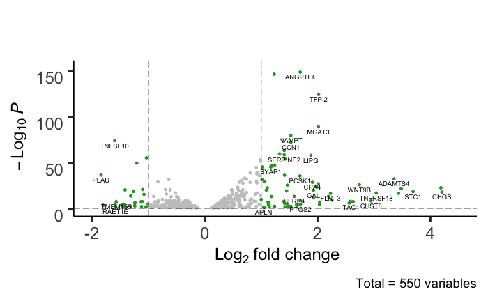

```r
go_volcano <- EnhancedVolcano(sigsecgenes,
                  lab = sigsecgenes$hgnc_symbol,
                  x = 'log2FoldChange',
                  y = 'pvalue',
                  selectLab = volc_genes,
                  FCcutoff = 1,
                  pCutoff = 0.05,
                  xlim = c(-2, 4.5),
                  pointSize = 1,
                  colCustom = keyvals.colour2,
                  labSize = 2.5,
                  title = '',
                  subtitle = "",
                  legendPosition = "none",
                  colAlpha = 1,
                  drawConnectors = F,
                  widthConnectors = 0.5,
                 # colConnectors = 'black',
                  boxedLabels = F,
                  legendLabSize = 10,
                  legendIconSize = 4.0,
                 gridlines.minor = F,
                 gridlines.major = F)


go_volcano
```

```r
#ggsave("transbato_volcano2.svg",go_volcano2,height = 5, width = 10)
```

#### Calculations for PCA of all genes vs secreted genes.

```r
# PCA calculations

pca_all <- prcomp(t(rld_mat))
pca_all_df <- cbind(coldata, pca_all$x)

rldgenes <-as.data.frame(rownames(rld_mat))
sectrimmed <- inner_join(secprot,rldgenes,by=c("ensemblid"="rownames(rld_mat)"))

rldsec <- rld_mat[sectrimmed$ensemblid,] %>% t()
pca_sec <- prcomp(rldsec)
dfsec <- cbind(coldata, pca_sec$x)
```

#### Plots to compare PCA using all genes vs secreted genes.

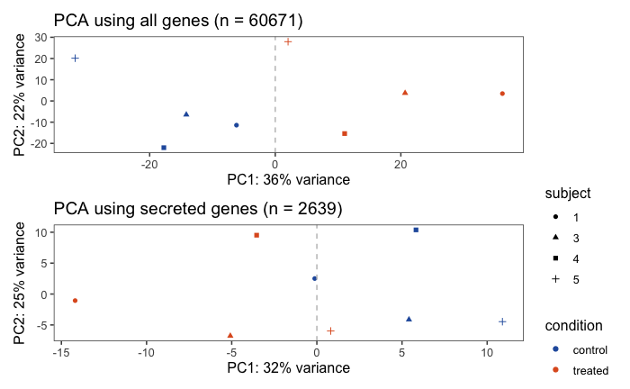

```r
# PCA comparison plot

percentVar_all <- round(100 * summary(pca_all)$importance[2,])
pca_allgenes <- ggplot(pca_all_df) +
  geom_point(aes(x=PC1, y=PC2, color = condition,shape=subject)) +
  xlab(paste0("PC1: ",percentVar_all[1],"% variance")) +
  ylab(paste0("PC2: ",percentVar_all[2],"% variance")) +
  geom_vline(xintercept = 0,linetype = 2,colour="grey") +
  theme_few() + theme(legend.position="none") +
  scale_colour_few("Dark") +
  ggtitle("PCA using all genes (n = 60671)")


percentVar_sec <- round(100 * summary(pca_sec)$importance[2,])
pca_secgenes <- ggplot(dfsec) +
  geom_point(aes(x=PC1, y=PC2, color = condition,shape=subject)) +
  xlab(paste0("PC1: ",percentVar_sec[1],"% variance")) +
  ylab(paste0("PC2: ",percentVar_sec[2],"% variance")) +
  geom_vline(xintercept = 0,linetype = 2,colour="grey") +
  theme_few() +
  scale_colour_few("Dark") +
  ggtitle("PCA using secreted genes (n = 2639)")



pcafig <- pca_allgenes / pca_secgenes
pcafig
```

```r
#ggsave('transbato_pca.png',pcafig,height=4,width=4*1.62)
```

#### Heatmap analysis of TGF family members to see change in expression

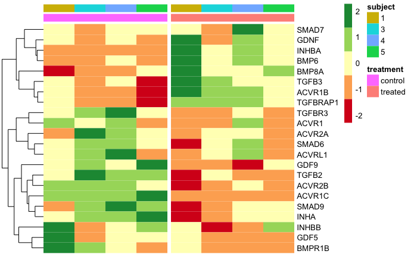

```r
# TGF beta family members

tgf_fam <- read_csv("tgfbeta_family_list.txt",col_names = FALSE)
tgf_list <- getBM(filters= "hgnc_symbol", attributes= c("ensembl_gene_id","hgnc_symbol","gene_biotype","description"),values=tgf_fam$X1,mart= mart)

de_list_all <- merge(siggenedf,G_list,by.x="ensemblid",by.y="ensembl_gene_id")

fft <- de_list_all$ensemblid %in% tgf_list$ensembl_gene_id

#DE list of TGF family
tgf_de <- de_list_all[fft,]

normcount_tgf <- normalized_counts[tgf_de$ensemblid,]
rownames(normcount_tgf) <- tgf_de$hgnc_symbol

# manually set heatmap column order
normcount_tgf <- normcount_tgf[,c(1,3,5,7,2,4,6,8)]

heat.colors <- brewer.pal(5, "RdYlGn")

pheatmap(normcount_tgf, color = heat.colors, cluster_rows = T,  show_rownames=T, cluster_cols = F, border_color=NA, fontsize = 10, scale="row",fontsize_row = 10, annotation_col = my_sample_col,gaps_col = c(4),show_colnames = F, annotation_names_col=F)
```

#### Counts for FSTL3

```r
# counts for FSTL3

nct <- data.frame(ensemblid = row.names(normalized_counts), normalized_counts,stringsAsFactors=FALSE)
rownames(nct) <- NULL
nct %>% filter_all(any_vars(. %in% c('ENSG00000070404')))
```

| ensemblid | X1_sample | X2_sample | X5_sample | X6_sample | X7_sample | X8_sample | X9_sample | X10_sample |
| --- | --- | --- | --- | --- | --- | --- | --- | --- |
| ENSG00000070404 | 2780.668 | 8226.743 | 2272.28 | 5591.695 | 2841.842 | 5926.158 | 2507.827 | 5137.966 |

```r
res <- results(dds)
design <- as.data.frame(colData(dds))
fstl3_count_fig <- degPlot(dds = dds, res = res, genes = c("ENSG00000070404"),xs = "condition",log2=F,xsLab="Norepinephrine treatment")
```

```
No genes were mapped to rowData. check ann parameter values.
```

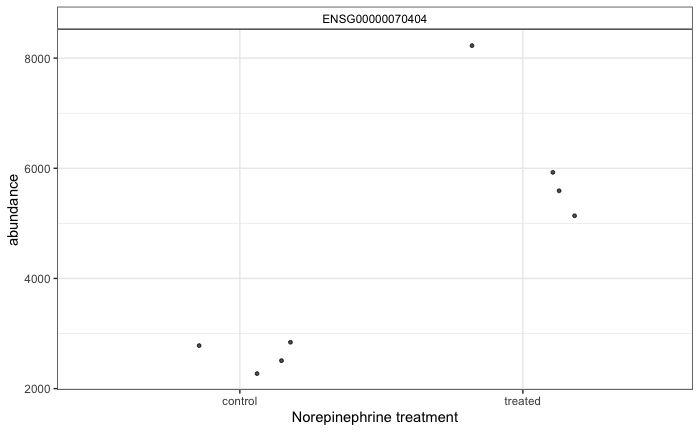

```r
fstl3_count_fig
```

```r
#ggsave('transbato_fstl3_normcount.png',fstl3_count_fig,height=4,width=4*0.6)
```